# Homeworksheet 6 - factorial designs – Answers!

Jeffrey A. Walker

23 October, 2023

# Learning Goals

1. Analysis of data from experiments with a two factor variables
2. Understanding interactions
3. Understanding how ANOVA is and is not like a regression model
4. log transformations and backtransformations
5. arithmetic v geometric mean

```r
knitr::opts_chunk$set(echo = TRUE)
# wrangling packages
library(here) # here makes a project transportable
library(janitor) # clean_names
library(readxl) # read excel, duh!
library(data.table) # magical data frames
library(magrittr) # pipes
library(stringr) # string functions
library(forcats) # factor functions

# analysis packages
library(emmeans) # the workhorse for inference
library(nlme) # gls and some lmm
library(lme4) # linear mixed models
library(lmerTest) # linear mixed model inference
library(afex) # ANOVA linear models
library(glmmTMB) # generalized linear models
library(MASS) # negative binomial and some other functions
library(car) # model checking and ANOVA
library(DHARMa) # model checking
library(mvtnorm)

# graphing packages
library(ggsci) # color palettes
library(ggpubr) # publication quality plots
library(ggforce) # better jitter
library(cowplot) # combine plots
library(knitr) # kable tables
library(kableExtra) # kable_styling tables

# ggplot_the_model.R packages not loaded above
library(insight)
library(lazyWeave)

# use here from the here package
here <- here::here
# use clean_names from the janitor package
clean_names <- janitor::clean_names

# load functions used by this text written by me
# ggplot_the_model.R needs to be in the folder "R"
# if you didn't download this and add to your R folder in your
# project, then this line will cause an error
source_path <- here("R", "ggplot_the_model.R")
source(source_path)

data_folder <- "data"
image_folder <- "images"
output_folder <- "output"
```

Source article: [Sinasac, David S., et al. “Genetic control of obesity, glucose homeostasis, dyslipidemia and fatty liver in a mouse model of diet-induced metabolic syndrome.” International Journal of Obesity 40.2 (2016): 346-355](https://www.nature.com/articles/ijo2015184)

data file: “MPG - data files for Molly B.xlsx”

data: Fig 1a (BW)

sheet: “1. Sinasac - B6 AJ diet”

This data file was given to me by Dr. Joe Nadeau (the senior author) who is archiving the file at Jackson labs, but I don’t think its there yet. Dr. Nadeau is a research faculty at Maine-Health Institute for Research (MHIR) so is a local – yaay!

Update: the data are archived here: https://phenome.jax.org/projects/Nadeau2

# Background

Metabolic syndrome is a collection of phenotypes related to the inability to properly regulate fat and glucose homeostasis and adipose tissue levels (in general, “syndrome” applied in medicine is a collection of similar symptoms that can have many, and often unknown causes). In this study, the researchers want to poke into the genetics of metabolic syndrome using different strains of mice. Fig. 1 shows the associations between strain, diet, and their interaction on different phenotypes related to metabolic syndrome. Table 1 reports the ANOVA statistics. Table 2 reports the group means (these should equal the estimated marginal means).

The two strains of mice are the C57BL/6J (“B6” or “black 6”) mice, which is the most common lab mouse for any kind of study and a strain that is susceptible to metabolic syndrome given a high fat diet, and the A/J mice, which is resistant to metabolic syndrome given a high fat diet. There are lots of phenotypes measures. Let’s use the first, which is body weight at 16 weeks (final_weight)

# Design

So this is a 2 x 2 factorial design. It is factorial because there is a group of mice assigned to each combination of all levels of each factor. That, is, the factors are fully **crossed**.

# Assignment

## Analyze the diet data

1. Follow the steps of the analysis including examine, fit a linear model, check the model, inference, and plot the model. Annotate your document with comments in the code and annotations in the text blocks (the space in between code chunks). I want to see comments on the examination of the data, on the model checks, and on the inference.
2. The analysis should follow the kinds of models that I am teaching, so use a linear model fit and not an anova model fit.
3. For the contrasts, report the “simple effect contrasts” (or simply “simple effects”) and not all 6 pairwise effects. Simple effects are described in 15.1.1. The method for computing the simple effects is in 15.11.3.3. For this, **do not adust the p-values** (a reason is that we might want to adjust for all the response variables simultaneouly…this is what the researchers did but using a very conservative adjustment)
4. Write a short result sentence.

### Import

```r
data_from <- "Genetic control of obesity, glucose homeostasis, dyslipidemia and fatty liver in a mouse model of diet-induced metabolic syndrome"
file_name <- "MPG - data files for Molly B.xlsx"
file_path <- here(data_folder, data_from, file_name)

fig1 <- read_excel(file_path,
                   sheet = "1. Sinasac - B6 AJ diet",
                   range = "A5:L75") %>%
  data.table() %>%
  clean_names()



fig1 <- na.omit(fig1) # get rid of NA rows

fig1[, genotype := factor(genotype,
                          levels = c("C57BL/6J", "A/J"))]
fig1[, diet := factor(diet,
                      levels = c("control", "HF/HS"))]
fig1[, treatment := paste(genotype, diet)]
```

### Think about the model before even examining the data

1. The data is body weight and morphometric measures (mass, lengths, areas) tend to have lognormal distributions. These are skewed right and the variance increases with the mean, so right away we might consider a gamma GLM (generalized linear model) for data like this. But we’ll see how the data look.
2. The design is 2 x 2 factorial, so we definitely want to fit a 2 factor linear model with interaction.

### Fit the models

```r
fig1_bw_m1 <- lm(final_bw ~ genotype * diet, data = fig1)
```

The coefficients give us the interaction effect

```r
coef(summary(fig1_bw_m1))
```

```
##                        Estimate Std. Error   t value     Pr(>|t|)
## (Intercept)           27.862941  0.8719273 31.955579 1.221611e-40
## genotypeA/J           -3.772941  1.2735313 -2.962582 4.299682e-03
## dietHF/HS             13.276471  1.2330914 10.766818 6.476963e-16
## genotypeA/J:dietHF/HS -7.549804  1.7607271 -4.287890 6.309120e-05
```

```r
confint(fig1_bw_m1)
```

```
##                           2.5 %    97.5 %
## (Intercept)            26.12053 29.605349
## genotypeA/J            -6.31789 -1.227992
## dietHF/HS              10.81233 15.740607
## genotypeA/J:dietHF/HS -11.06834 -4.031272
```

### Check the model

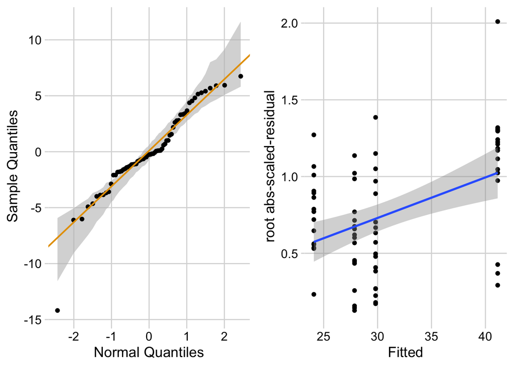

```r
ggcheck_the_model(fig1_bw_m1)
```

The QQ plot is consistent with sampling from a normal distribution. Certainly if it were lognormal then we’d see points on the right hand side much more positive than the gray area.

The scale-location plot shows variance increasing with mean expected of lognormal data but most of this is due to the one group.

So we might want to think about a GLM for lognormal data such as the gamma distribution. The authors went a different route and log transformed the response. The log transformation is extremely common in classically trained statistics (like 1980s-1990s ecology) but less common now that GLM models are easy to solve on modern computers.

Regardless, we’ll stick to the linear model with untransformed response to start.

```r
fig1_bw_emm <- emmeans(fig1_bw_m1, specs = c("genotype", "diet"))
fig1_bw_simple <- contrast(fig1_bw_emm,
                     method = "revpairwise",
                     simple = "each",
                     combine = TRUE,
                     adjust = "none") %>%
  summary(infer = TRUE)

fig1_bw_simple
```

```
##  diet    genotype contrast           estimate   SE df lower.CL upper.CL t.ratio
##  control .        (A/J) - (C57BL/6J)    -3.77 1.27 63    -6.32    -1.23  -2.963
##  HF/HS   .        (A/J) - (C57BL/6J)   -11.32 1.22 63   -13.75    -8.89  -9.313
##  .       C57BL/6J (HF/HS) - control     13.28 1.23 63    10.81    15.74  10.767
##  .       A/J      (HF/HS) - control      5.73 1.26 63     3.22     8.24   4.556
##  p.value
##   0.0043
##   <.0001
##   <.0001
##   <.0001
##
## Confidence level used: 0.95
```

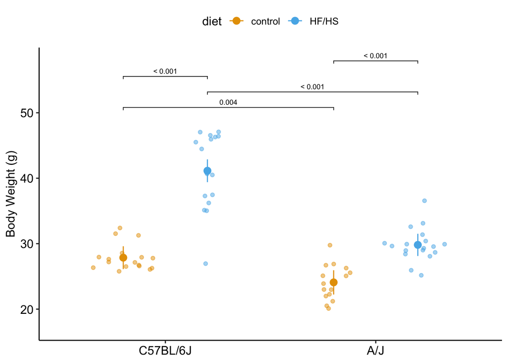

```r
ggplot_the_response(fig1_bw_m1, fig1_bw_emm, fig1_bw_simple,
                    y_label = "Body Weight (g)")
```

A HF diet increases BW in both strains, but the effect is attenuated in the A/J strain (C57BL/6J: 13.28 g, CI 10.81 to 15.74, p < 0.0001, AJ: 5.73 g, CI 3.22 to 8.24, Interaction -7.55 g, CI -11.1 to -4.0, p < 0.001).

## Better know ANOVA – exploring ANOVA

1. fit a two-way ANOVA with interaction using the `aov` function. Report the ANOVA table here.

```r
fig1_bw_aov1 <- aov(final_bw ~ genotype * diet, data = fig1)
summary(fig1_bw_aov1)
```

```
##               Df Sum Sq Mean Sq F value   Pr(>F)
## genotype       1  889.4   889.4   68.81 1.09e-11 ***
## diet           1 1528.9  1528.9  118.30 4.26e-16 ***
## genotype:diet  1  237.6   237.6   18.39 6.31e-05 ***
## Residuals     63  814.2    12.9
## ---
## Signif. codes:  0 '***' 0.001 '**' 0.01 '*' 0.05 '.' 0.1 ' ' 1
```

2. fit a two-way ANOVA using the “safe ANOVA” method given in 15.11.4.2

```r
type3 <- list(genotype = contr.sum,
              diet = contr.sum)
fig1_bw_m3 <- lm(final_bw ~ genotype * diet,
                    data = fig1,
                    contrasts = type3)
fig1_bw_m3_aov <- Anova(fig1_bw_m3, type="3")[-1, -1]  # delete row 1 and col 1
fig1_bw_m3_aov
```

```
##               Df F value    Pr(>F)
## genotype       1  73.506 3.559e-12 ***
## diet           1 116.484 5.865e-16 ***
## genotype:diet  1  18.386 6.309e-05 ***
## Residuals     63
## ---
## Signif. codes:  0 '***' 0.001 '**' 0.01 '*' 0.05 '.' 0.1 ' ' 1
```

**QUESTION** – the p-values from the two ANOVA tables differ. Why? Under what condition would the p-values be the same?

The p-values differ because they use different methods of summing the squared residuals. The different methods give the same result if the data are balanced but the data are not balanced here.

## Replicate the published ANOVA

The published ANOVA differs from my safe-practice ANOVA because the researchers log 2 transformed the response. There are two ways to do this. One could create a new column in the data.table

```r
fig1[, log2_final_bw := log2(final_bw)]
```

or one could simply use the transformation in the model formula, like this:

```r
log2(final_bw) ~ genotype * diet
```

The advantage of doing this in the formula is that the emmeans package is smart enough to see that the response is transformed and so can return tables (emmeans and contrasts) of **backtransformed** values (the stats are done on the log scale but its hard to interpret a mean on a log2 scale!)

so

1. Repeat the safe-practice two-way ANOVA above but using the log2 transformed response in the model formula.

```r
type3 <- list(genotype = contr.sum,
              diet = contr.sum)
fig1_bw_m4 <- lm(log2(final_bw) ~ genotype * diet,
                    data = fig1,
                    contrasts = type3)
fig1_bw_m4_aov <- Anova(fig1_bw_m4, type="3")[-1, -1]  # delete row 1 and col 1

fig1_bw_m4_aov
```

```
##               Df  F value    Pr(>F)
## genotype       1  75.9792 2.007e-12 ***
## diet           1 125.9357 < 2.2e-16 ***
## genotype:diet  1   9.7155  0.002752 **
## Residuals     63
## ---
## Signif. codes:  0 '***' 0.001 '**' 0.01 '*' 0.05 '.' 0.1 ' ' 1
```

The F-ratios of the above table are effectively equal (to the 2nd decimal place) to the F-ratios in table 1. But the p-values for the interaction is still not that in the published table 1 (there is no value in table 1 but there is a “NS” meaning the value is not statistically significant at 0.05, so we know the p-value is greater than 0.05). To get the value in the published table, we have to adjust our value using the bonferroni. There are $10 \times 3 = 30$ tests in table 1. So we can bonferroni adjust any p-value by multiplying the unadjusted value by 30. Do this.

```r
fig1_bw_m4_aov$adj_p <- fig1_bw_m4_aov$"Pr(>F)"*30

fig1_bw_m4_aov
```

```
##               Df  F value    Pr(>F)    adj_p
## genotype       1  75.9792 0.0000000 0.000000
## diet           1 125.9357 0.0000000 0.000000
## genotype:diet  1   9.7155 0.0027522 0.082565
## Residuals     63
```

**QUESTION** What is the bonferroni adjusted interaction p-value for the untransformed response (you can use that from either the lm, the unsafe ANOVA, or the safe-ANOVA as these should be the same)? What can we conclude inference for the interaction from the 1) untransformed and from the 2) transformed response?

```r
fig1_bw_m3_aov$adj_p <- fig1_bw_m3_aov$"Pr(>F)"*30

fig1_bw_m3_aov
```

```
##               Df F value     Pr(>F)     adj_p
## genotype       1  73.506 0.0000e+00 0.0000000
## diet           1 116.484 0.0000e+00 0.0000000
## genotype:diet  1  18.386 6.3091e-05 0.0018927
## Residuals     63
```

The intereraction using the log-transformed data has a small but but not really small bonferroni adjusted p-value (p = 0.08) while the interaction using the untransformed data has a very small bonferroni adjusted p-value (p = 0.002).

Why bonferroni adjust of all 30 p-values (two main effects and one interaction effect for 10 response variables)? Good question! 1. First, it would make more sense to use a Holm or FDR adjustment. Bonferroni is very conservative 2. Second, we could use a Tukey within any of the response variables but can’t combine all 10 response variables and use Tukey. Can do this with Bonferroni/Holm/FDR because for these all one needs is a column of p-values. 3. Adjusting means we are asking the question “if we compare High vs. Low fat diet in two strains of mice, will we find any kind of effect of diet or strain or interaction in any of the 10 response variables.” This is a very exploratory question.

## Better know backtransformations

1. Print the estimated marginal means table from the linear model fit to the untransformed response (part 1 of the assignment)
2. Compute and print the estimated marginal means table from the linear model fit to the log2 transformed response (part 3 of the assignment). Be sure to backtransform the means by using the argument `type = "response"`

Compare the means between the tables – they differ! [The mean of the untransformed values is not equal to the backtransformed mean of the transformed values] (https://en.wikipedia.org/wiki/Inequality_of_arithmetic_and_geometric_means){target=“_blank”}. The 2nd mean is called a **geometric mean** and there are a couple of ways of thinking about what these are (follow that link to read more about this!).

Why this matters – when we compare means, we think that we are comparing the arithmetic means (what is reported in table 2) but if we log transform the response then we are comparing the geometric means. So the p-value and test is not of what we think it is. This has quantitative consequences of the p-value. Does it make sense to conclude “no interaction” if we compute the p-value on log-transformed response and “interaction” on untransformed response? This is a problem with the dichotomization of p-values – thinking that p < 0.05 means one thing and p > 0.05 means another. Its all just imperfect evidence against a very simple model (no effects!) that we know from the beginning is unlikely to be strictly true!

```r
m1 <- lm(final_bw ~ genotype * diet, data = fig1)
emmeans(m1, specs = c("genotype", "diet"))
```

```
##  genotype diet    emmean    SE df lower.CL upper.CL
##  C57BL/6J control   27.9 0.872 63     26.1     29.6
##  A/J      control   24.1 0.928 63     22.2     25.9
##  C57BL/6J HF/HS     41.1 0.872 63     39.4     42.9
##  A/J      HF/HS     29.8 0.847 63     28.1     31.5
##
## Confidence level used: 0.95
```

```r
m2 <- lm(log2(final_bw) ~ genotype * diet, data = fig1)
emmeans(m2, specs = c("genotype", "diet"), type = "response")
```

```
##  genotype diet    response    SE df lower.CL upper.CL
##  C57BL/6J control     27.8 0.733 63     26.4     29.3
##  A/J      control     23.9 0.672 63     22.6     25.3
##  C57BL/6J HF/HS       40.7 1.073 63     38.6     42.9
##  A/J      HF/HS       29.7 0.761 63     28.2     31.3
##
## Confidence level used: 0.95
## Intervals are back-transformed from the log2 scale
```

### For fun, lets compare a gamma GLM

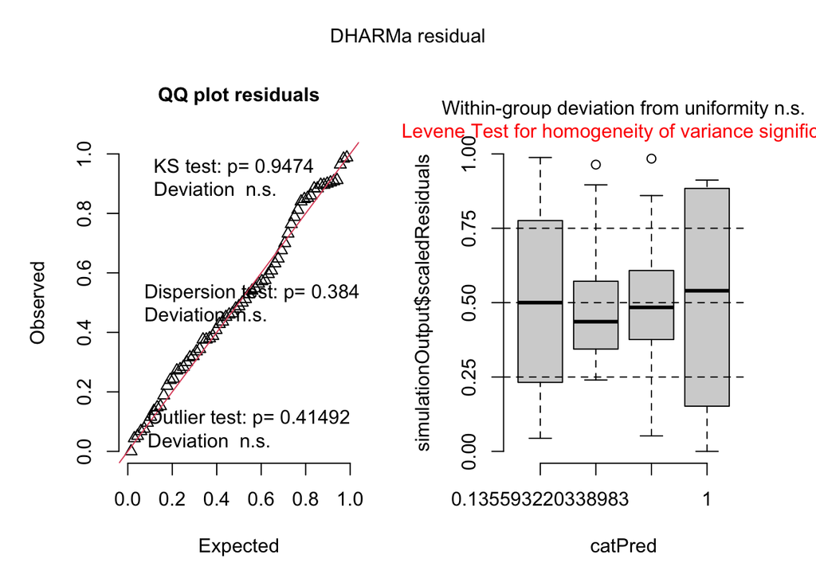

```r
m3 <- glm(final_bw ~ genotype * diet,
          family = Gamma(link = "log"),
          data = fig1)
m3_check <- simulateResiduals(fittedModel = m3,
                                       n = 250,
                                       refit = FALSE)
plot(m3_check)
```

```r
coef(summary(m1))
```

```
##                        Estimate Std. Error   t value     Pr(>|t|)
## (Intercept)           27.862941  0.8719273 31.955579 1.221611e-40
## genotypeA/J           -3.772941  1.2735313 -2.962582 4.299682e-03
## dietHF/HS             13.276471  1.2330914 10.766818 6.476963e-16
## genotypeA/J:dietHF/HS -7.549804  1.7607271 -4.287890 6.309120e-05
```

```r
coef(summary(m2))
```

```
##                         Estimate Std. Error    t value     Pr(>|t|)
## (Intercept)            4.7969349 0.03803180 126.129582 1.883948e-77
## genotypeA/J           -0.2150246 0.05554900  -3.870899 2.601138e-04
## dietHF/HS              0.5506174 0.05378509  10.237362 4.975283e-15
## genotypeA/J:dietHF/HS -0.2393821 0.07679954  -3.116973 2.752157e-03
```

```r
coef(summary(m3))
```

```
##                         Estimate Std. Error    t value     Pr(>|t|)
## (Intercept)            3.3272975 0.02560654 129.939356 2.910334e-78
## genotypeA/J           -0.1455007 0.03740075  -3.890316 2.439031e-04
## dietHF/HS              0.3896691 0.03621312  10.760439 6.636842e-16
## genotypeA/J:dietHF/HS -0.1763983 0.05170859  -3.411393 1.133390e-03
```